# RQ3 Analyses — Distributional Equivalence and Correlation Correspondence

Bootstrap CIs · BCa sensitivity · Welch t · Levene · Fisher z · Spearman

Author

Caroline Müller

Published

May 17, 2026

# 1 Overview

**Prerequisite:** Run `30_RQ3_data.qmd` first to generate `d_rq3_merged.rds` in `10_data/80_analyses_exports/`.

This file covers all inferential RQ3 analyses:

- **RQ3a** Distributional equivalence: delta-M (Welch t) and delta-SD (Levene’s) with bootstrap percentile CIs
- **RQ3b** Correlation correspondence: Pearson r per group + Fisher’s z-difference test + Spearman robustness
- **BCa sensitivity** checks for delta-SD and delta-r (bounded/skewed)

**Primary CIs:** Bootstrap percentile, R = 10,000, stratified by `id_type`.  
**Sensitivity CIs:** BCa for delta-SD and delta-r; divergence threshold = 0.02.

**Note:** The `id_type = "AI"` group is the short-3 matched condition from `d_rq3_merged`. All inferential claims about means and SDs are for this matched condition only; multi-condition AI comparisons are in `20_RQ2_analyses.qmd`.

# 2 Setup

## 2.1 Environment

## 2.2 Shared Constants

## 2.3 Load Upstream Export

## 2.4 Helpers

# 3 Assumption Checks

## 3.1 Univariate Normality

Shapiro-Wilk at N ≈ 400 is overpowered; significant results are expected for trivially small deviations. We use Q-Q plots as the primary diagnostic; skewness and kurtosis are reported for reference.

Figure 1: Univariate Q-Q Plots by Group and Need Dimension. Substantial departures from the diagonal support non-normality.

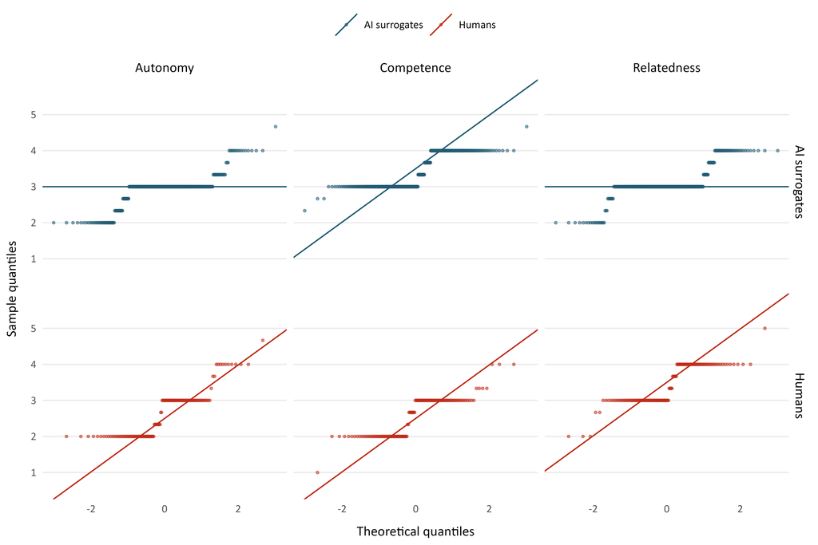

## 3.2 Linearity Check

Figure 2: Linearity Check: LLM score vs questionnaire score by group and need. LOESS (solid) vs OLS (dashed).

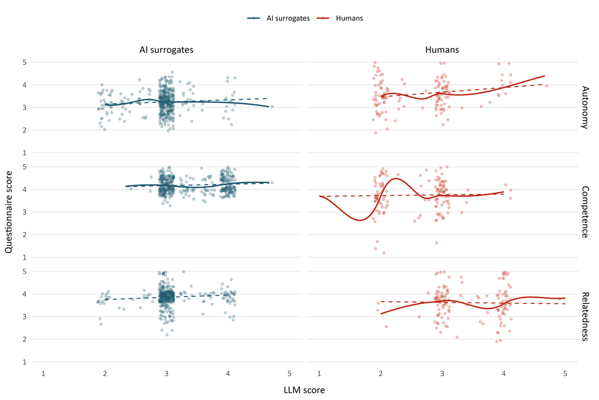

# 4 RQ3a — Distributional Equivalence

RQ3a asks: to what extent do distributional properties (mean, SD) differ between AI surrogate and human participant data?

## 4.1 Bootstrap delta-M

Stratified bootstrap: resample within AI and human groups separately. Set.seed(2026) before each `boot::boot()` call.

## 4.2 BCa Sensitivity Check — delta-M

## 4.3 Bootstrap delta-SD

## 4.4 BCa Sensitivity Check — delta-SD

## 4.5 Welch t-test and Levene’s Test

## 4.6 RQ3a Results Table

Table 1: RQ3a: Distributional Equivalence — Welch t-test and Levene’s Test by Need Dimension

| Need | N (AI) | N (HU) | M (AI) | M (HU) | SD (AI) | SD (HU) | Δ M | 95% CI (Δ M) | t | df | p | Δ SD | 95% CI (Δ SD) | F | df | p |
| --- | --- | --- | --- | --- | --- | --- | --- | --- | --- | --- | --- | --- | --- | --- | --- | --- |
| Autonomy | 394 | 132 | 2.94 | 2.66 | 0.40 | 0.64 | 0.27 | [0.16, 0.39] | 4.58 | 165.9 | 0 | -0.24 | [-0.32, -0.16] | 102.28 | 1, 524 | 0.000 |
| Competence | 394 | 132 | 3.41 | 2.58 | 0.47 | 0.55 | 0.82 | [0.72, 0.93] | 15.44 | 199.2 | 0 | -0.08 | [-0.14, -0.03] | 10.68 | 1, 524 | 0.001 |
| Relatedness | 394 | 132 | 3.07 | 3.42 | 0.40 | 0.54 | -0.35 | [-0.45, -0.24] | -6.73 | 181.5 | 0 | -0.14 | [-0.21, -0.07] | 75.38 | 1, 524 | 0.000 |

Note. Δ M = M(AI) − M(HU); bootstrap percentile CIs, R = 10000, stratified by group, seed = 2026. Welch t-test (var.equal = FALSE). Levene's test (center = mean). BCa sensitivity: see check_bca_divergence_delta_m, check_bca_divergence_delta_sd.

## 4.7 RQ3a Bar Plot

Figure 3: RQ3a: LLM Score Means by Group and Need Dimension. Error bars = approximate 95% CI (M ± 1.96 SE, normal theory, illustrative). Inferential tests in tbl-rq3a-results.

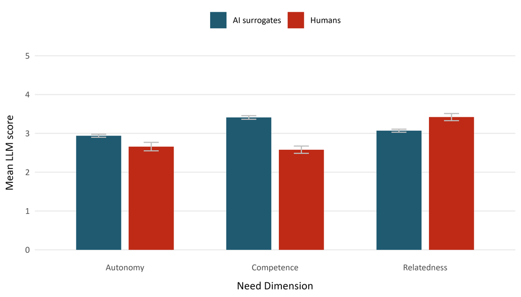

# 5 RQ3b — Correlation Correspondence

RQ3b asks: to what extent do LLM–questionnaire correlations differ between AI surrogates and human participants?

## 5.1 Bootstrap delta-r

## 5.2 BCa Sensitivity Check — delta-r

## 5.3 Fisher z-difference Test and Results

## 5.4 RQ3b Results Table

Table 2: RQ3b: Correlation Correspondence — Pearson r per Group and Fisher z-Difference by Need Dimension

| Need | r (AI) | r (HU) | N (AI) | N (HU) | Δ r | 95% CI (Δ r) | z | p |
| --- | --- | --- | --- | --- | --- | --- | --- | --- |
| Autonomy | 0.07 | 0.19 | 394 | 132 | -0.11 | [-0.29, 0.08] | 1.11 | 0.267 |
| Competence | 0.09 | 0.02 | 394 | 132 | 0.06 | [-0.12, 0.25] | 0.60 | 0.547 |
| Relatedness | 0.09 | -0.02 | 394 | 132 | 0.12 | [-0.08, 0.31] | 1.16 | 0.247 |

Note. r = Pearson LLM–questionnaire correlation. Δ r = r(AI) − r(HU); bootstrap percentile CIs, R = 10000, stratified by group, seed = 2026. Fisher z-difference test via psych::r.test(), two independent groups. BCa sensitivity: see check_bca_divergence_delta_r.

## 5.5 RQ3b Scatter Plot

Figure 4: RQ3b: LLM score vs questionnaire score by group and need dimension. LOESS (solid), OLS (dashed). Pearson r annotated per panel.

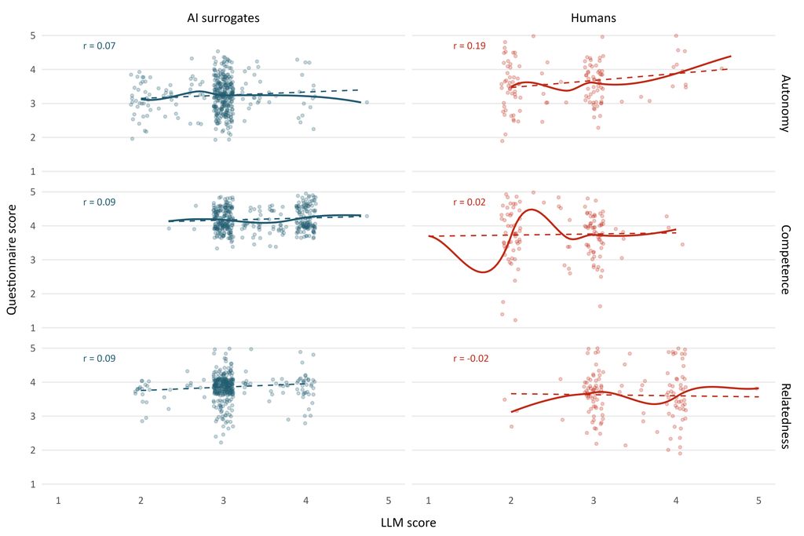

## 5.6 Spearman Robustness

Table 3: RQ3b Spearman Robustness: Rho per Group and Delta-rho with Percentile CIs

| Need | ρ (AI) | ρ (HU) | Δ ρ | 95% CI (Δ ρ) |
| --- | --- | --- | --- | --- |
| Autonomy | 0.06 | 0.14 | -0.08 | [-0.27, 0.12] |
| Competence | 0.05 | 0.00 | 0.05 | [-0.13, 0.25] |
| Relatedness | 0.12 | -0.01 | 0.13 | [-0.06, 0.33] |

Note. Spearman rho on unrounded continuous scores. Δ ρ bootstrap percentile CIs, R = 1000, stratified by group. Compare with Pearson r in tbl-rq3b-results.

# 6 Appendix: BCa Sensitivity Tables

Table 4: Appendix: BCa vs Percentile CIs for Delta-M — All 3 Need Dimensions

| need | perc_lo | perc_hi | bca_lo | bca_hi | max_diff |
| --- | --- | --- | --- | --- | --- |
| Autonomy | 0.156 | 0.388 | 0.153 | 0.383 | 0.004 |
| Competence | 0.719 | 0.928 | 0.719 | 0.928 | 0.000 |
| Relatedness | -0.446 | -0.244 | -0.445 | -0.243 | 0.001 |

Note. Divergence threshold = 0.02. Cells with max_diff > 0.02 also reported in check_bca_divergence_delta_m.

Table 5: Appendix: BCa vs Percentile CIs for Delta-SD — All 3 Need Dimensions

| need | perc_lo | perc_hi | bca_lo | bca_hi | max_diff |
| --- | --- | --- | --- | --- | --- |
| Autonomy | -0.325 | -0.157 | -0.327 | -0.158 | 0.002 |
| Competence | -0.136 | -0.025 | -0.147 | -0.032 | 0.011 |
| Relatedness | -0.209 | -0.073 | -0.214 | -0.077 | 0.004 |

Note. Divergence threshold = 0.02. Cells with max_diff > 0.02 also reported in check_bca_divergence_delta_sd.

Table 6: Appendix: BCa vs Percentile CIs for Delta-r — All 3 Need Dimensions

| need | perc_lo | perc_hi | bca_lo | bca_hi | max_diff |
| --- | --- | --- | --- | --- | --- |
| Autonomy | -0.292 | 0.084 | -0.295 | 0.081 | 0.004 |
| Competence | -0.119 | 0.246 | -0.118 | 0.247 | 0.002 |
| Relatedness | -0.081 | 0.308 | -0.073 | 0.314 | 0.007 |

Note. Divergence threshold = 0.02. Cells with max_diff > 0.02 also reported in check_bca_divergence_delta_r.

# 7 Session Info